# Logistic and linear regression with deterministic and stochastic first order methods

```
Lab 2 : Optimisation - DataScience Master
Authors : Alexandre Gramfort, Hicham Janati
```

The aim of this lab is to implement and compare various batch and stochastic algorithms for linear and logistic regression with ridge penalization.

The following methods are compared in this notebook.

**Batch (deterministic) methods**

- gradient descent (GD)
- accelerated gradient descent (AGD)

**Stochastic algorithms**

- stochastic gradient descent (SGD)
- stochastic averaged gradient (SAG)
- stochastic variance reduced gradient (SVRG)

Note that we consider as use-cases logistic and linear regression with ridge penalization only, although most of the algorithms below can be used with many other models, and other types of penalization, even non-smooth ones, such as the $\ell_1$ penalization.

## VERY IMPORTANT

- This work **must be done by pairs of students**.
- **Each** student must send their work **before the 14th of November at 23:55**, using the **moodle platform**.
- This means that **each student in the pair sends the same file**
- The **name of the file must be** constructed as in the next cell

### How to construct the name of your file

```python
# Change here using YOUR first and last names
fn1 = "marius"
ln1 = "ortega"
fn2 = "wiam"
ln2 = "adnan"

filename = "_".join(map(lambda s: s.strip().lower(),
                        ["lab2", ln1, fn1, "and", ln2, fn2])) + ".ipynb"
print(filename)
```

```
lab2_ortega_marius_and_adnan_wiam.ipynb
```

# Gentle reminder: no evaluation if you don't respect this EXACTLY

### Table of content

1. Loss functions, gradients and step-sizes  
2. Generate a dataset  
3. Deterministic methods  
4. Stochastic methods  
5. Numerical comparison  
6. Conclusion

```python
%matplotlib inline
```

```python
from time import time

import numba
import numpy as np
from scipy.linalg import norm
import matplotlib.pyplot as plt
from numba import njit
```

```python
# choose a large font size by default and use tex for math
usetex = False  # change this to True if you have a working LaTeX install

fontsize = 16
params = {
    "axes.labelsize": fontsize + 2,
    "font.size": fontsize + 2,
    "legend.fontsize": fontsize + 2,
    "xtick.labelsize": fontsize,
    "ytick.labelsize": fontsize,
    "text.usetex": usetex,
}
plt.rcParams.update(params)
```

## 0. Make sure Numba is correctly installed

Instructions available at: http://numba.pydata.org/numba-doc/latest/user/installing.html

```python
print(numba.__version__) # Your version of Numba
```

```
0.58.1
```

```python
@njit
def go_fast(a): # Function is compiled to machine code when called the first time
    trace = 0.0
    # assuming square input matrix
    for i in range(a.shape[0]):   # Numba likes loops
        trace += np.tanh(a[i, i]) # Numba likes NumPy functions
    return a + trace              # Numba likes NumPy broadcasting

x = np.arange(100).reshape(10, 10)
x = x.astype(float)
go_fast(x) # Running a first time the function to compile it
```

```
array([[  9.,  10.,  11.,  12.,  13.,  14.,  15.,  16.,  17.,  18.],
       [ 19.,  20.,  21.,  22.,  23.,  24.,  25.,  26.,  27.,  28.],
       [ 29.,  30.,  31.,  32.,  33.,  34.,  35.,  36.,  37.,  38.],
       [ 39.,  40.,  41.,  42.,  43.,  44.,  45.,  46.,  47.,  48.],
       [ 49.,  50.,  51.,  52.,  53.,  54.,  55.,  56.,  57.,  58.],
       [ 59.,  60.,  61.,  62.,  63.,  64.,  65.,  66.,  67.,  68.],
       [ 69.,  70.,  71.,  72.,  73.,  74.,  75.,  76.,  77.,  78.],
       [ 79.,  80.,  81.,  82.,  83.,  84.,  85.,  86.,  87.,  88.],
       [ 89.,  90.,  91.,  92.,  93.,  94.,  95.,  96.,  97.,  98.],
       [ 99., 100., 101., 102., 103., 104., 105., 106., 107., 108.]])
```

```python
np.tanh(0)+ np.tanh(10) + np.tanh(20)
```

```
1.9999999958776926
```

Iteration time of the Numba-compiled function.

```python
%timeit go_fast(x)
```

```
1.52 µs ± 466 ns per loop (mean ± std. dev. of 7 runs, 1,000,000 loops each)
```

Numba-compiled function have a special `.py_func` attribute which is the original uncompiled Python function. Iteration time of the uncompiled function should be greater.

```python
%timeit go_fast.py_func(x)
```

```
16.8 µs ± 3.36 µs per loop (mean ± std. dev. of 7 runs, 100,000 loops each)
```

## 1. Loss functions, gradients and step-sizes

We want to minimize $$ \frac 1n \sum_{i=1}^n \ell(a_i^\top x, b_i) + \frac \lambda 2 \|x\|_2^2 $$ where

- $\ell(z, b) = \frac 12 (b - z)^2$ (least-squares regression)
- $\ell(z, b) = \log(1 + \exp(-bz))$ (logistic regression).

We write it as a minimization problem of the form $$ \frac 1n \sum_{i=1}^n f_i(x) $$ where $$ f_i(x) = \ell(a_i^\top x, b_i) + \frac \lambda 2 \|x\|_2^2. $$

For each cases, the gradients are $$ \nabla f_i(x) = (a_i^\top x - b_i) a_i + \lambda x $$ and $$ \nabla f_i(x) = - \frac{b_i}{1 + \exp(b_i a_i^\top x)} a_i + \lambda x. $$

Denote by $L$ (resp. $L_i$) the Lipschitz constant of $f$ (resp. $f_i$) and $\mathbf A^\top = [a_1, \ldots, a_n].$ One can easily see (using $\|\cdot\|_{2}$ for the matrix spectrale norm) that for least-squares regression $$ L = \frac{ \|\mathbf A^\top \mathbf A \|_{2}}{n} + \lambda \quad \text{ and } L_i = \| a_i \|_2^2 + \lambda $$ while for logistic regression it is $$ L = \frac{ \|\mathbf A^\top \mathbf A \|_{2}}{4 n} + \lambda \quad \text{ and } L_i = \frac 14 \| a_i \|_2^2 + \lambda. $$ For full-gradient methods, the theoretical step-size is $1 / L$, while for SAG and SVRG (see below) it can be taken as $1 / (\max_{i=1,\ldots,n} L_i)$

We now introduce functions that will be used for the solvers.

```python
@njit
def grad_i_linreg(i, x, A, b, lbda):
    """Gradient with respect to a sample"""
    a_i = A[i]
    return (a_i.dot(x) - b[i]) * a_i + lbda * x


@njit
def grad_linreg(x, A, b, lbda):
    """Full gradient"""
    g = np.zeros_like(x)
    n = A.shape[0]
    for i in range(n):
        g += grad_i_linreg(i, x, A, b, lbda)
    return g / n


def loss_linreg(x, A, b, lbda):
    n = A.shape[0]
    return norm(A.dot(x) - b) ** 2 / (2. * n) + lbda * norm(x) ** 2 / 2.


def lipschitz_linreg(A, b, lbda):
    n = A.shape[0]
    return norm(A, ord=2) ** 2 / n + lbda
```

```python
@njit
def grad_i_logreg(i, x, A, b, lbda):
    """Gradient with respect to a sample"""
    a_i = A[i]
    b_i = b[i]
    return - a_i * b_i / (1. + np.exp(b_i * np.dot(a_i, x))) + lbda * x


@njit
def grad_logreg(x, A, b, lbda):
    """Full gradient"""
    g = np.zeros_like(x)
    n = A.shape[0]
    for i in range(n):
        g += grad_i_logreg(i, x, A, b, lbda)
    return g / n


def loss_logreg(x, A, b, lbda):
    bAx = b * np.dot(A, x)
    return np.mean(np.log(1. + np.exp(- bAx))) + lbda * norm(x) ** 2 / 2.


def lipschitz_logreg(A, b, lbda):
    n = A.shape[0]
    return norm(A, ord=2) ** 2 / (4. * n) + lbda
```

## 2. Generate a dataset

We generate datasets for the least-squares and the logistic cases. First we define a function for the least-squares case.

```python
from numpy.random import multivariate_normal, randn
from scipy.linalg import toeplitz


def simu_linreg(x, n, std=1., corr=0.5):
    """Simulation for the least-squares problem.

    Parameters
    ----------
    x : ndarray, shape (d,)
        The coefficients of the model
    n : int
        Sample size
    std : float, default=1.
        Standard-deviation of the noise
    corr : float, default=0.5
        Correlation of the features matrix

    Returns
    -------
    A : ndarray, shape (n, d)
        The design matrix.
    b : ndarray, shape (n,)
        The targets.
    """
    d = x.shape[0]
    cov = toeplitz(corr ** np.arange(0, d))
    A = multivariate_normal(np.zeros(d), cov, size=n)
    noise = std * randn(n)
    b = A.dot(x) + noise
    return A, b
```

```python
def simu_logreg(x, n, std=1., corr=0.5):
    """Simulation for the logistic regression problem.

    Parameters
    ----------
    x : ndarray, shape (d,)
        The coefficients of the model
    n : int
        Sample size
    std : float, default=1.
        Standard-deviation of the noise
    corr : float, default=0.5
        Correlation of the features matrix

    Returns
    -------
    A : ndarray, shape (n, d)
        The design matrix.
    b : ndarray, shape (n,)
        The targets.
    """
    A, b = simu_linreg(x, n, std=1., corr=corr)
    return A, np.sign(b)
```

```python
d = 50
n = 10000
idx = np.arange(d)

# Ground truth coefficients of the model
x_model_truth = (-1)**idx * np.exp(-idx / 10.)

_A, _b = simu_linreg(x_model_truth, n, std=1., corr=0.1)
#_A, _b = simu_logreg(x_model_truth, n, std=1., corr=0.7)
```

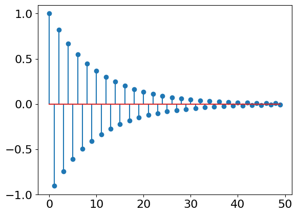

```python
plt.stem(x_model_truth);
```

### Numerically check loss and gradient

```python
from scipy.optimize import check_grad

lbda = 1. / n ** (0.5)

A, b = simu_linreg(x_model_truth, n, std=1., corr=0.1)
# Check that the gradient and the loss numerically match
check_grad(loss_linreg, grad_linreg, np.random.randn(d), A, b, lbda)
```

```
1.2458386568951847e-05
```

```python
lbda = 1. / n ** (0.5)

A, b = simu_logreg(x_model_truth, n, std=1., corr=0.1)
# Check that the gradient and the loss numerically match
check_grad(loss_logreg, grad_logreg, np.random.randn(d), A, b, lbda)
```

```
1.4695570673700713e-07
```

### Choice of the model

```python
A, b = simu_linreg(x_model_truth, n, std=1., corr=0.9)
loss = loss_linreg
grad = grad_linreg
grad_i = grad_i_linreg
lipschitz_constant = lipschitz_linreg
lbda = 1. / n ** (0.5)
```

### Compute the theoretical step-size for gradient descent

```python
step = 1. / lipschitz_constant(A, b, lbda)

print("step = %s" % step)
```

```
step = 0.06372586646377906
```

### Get a very precise minimum to compute distances to minimum

Here we use L-BFGS that you have not seen yet. Just take the estimated `x_min` and move on. You will see L-BFGS later in the course.

```python
from scipy.optimize import fmin_l_bfgs_b

x_init = np.zeros(d)
x_min, f_min, _ = fmin_l_bfgs_b(loss, x_init, grad,
                                args=(A, b, lbda), pgtol=1e-30, factr=1e-30)


print(f_min)
print(norm(grad_linreg(x_min, A, b, lbda)))
```

```
0.5325781538286459
3.097264490669532e-08
```

## 3. Deterministic/Batch methods (GD, AGD)

### Define a class to monitor iterations

```python
class monitor:
    def __init__(self, algo, loss, x_min, args=()):
        self.x_min = x_min
        self.algo = algo
        self.loss = loss
        self.args = args
        self.f_min = loss(x_min, *args)

    def run(self, *algo_args, **algo_kwargs):
        t0 = time()
        _, x_list = self.algo(*algo_args, **algo_kwargs)
        self.total_time = time() - t0
        self.x_list = x_list
        self.err = [norm(x - self.x_min) for x in x_list]
        self.obj = [self.loss(x, *self.args) - self.f_min for x in x_list]
```

```python
# Number of iterations
n_iter = 200
```

### Gradient descent (GD)

We recall that an iteration of batch gradient writes

$$ x_{k+1} \gets x_k - \eta \nabla f(x_k) $$

where $\eta$ is the step-size (that can be chosen in theory as $\eta = 1 / L$, with $L$ the Lipshitz constant of $\nabla f$, see above)

*QUESTION*:

- Fill in the iteration of the GD solver in the cell below

```python
@njit
def gd(x_init, grad, n_iter=100, step=1., store_every=1, args=()):
    """Gradient descent algorithm."""
    x = x_init.copy()
    x_list = []
    for i in range(n_iter):
        x = x - step * grad(x, *args)
        if i % store_every == 0:
            x_list.append(x.copy())
    return x, x_list
```

```python
step = 1. / lipschitz_linreg(A, b, lbda)
x_init = np.zeros(d)
monitor_gd = monitor(gd, loss, x_min, (A, b ,lbda))
monitor_gd.run(x_init, grad, n_iter, step, args=(A, b, lbda))
```

### Accelerated Gradient Descent (AGD)

We recall that an iteration of AGD (see FISTA) writes:

$$ \begin{align*} x_{k+1} &\gets y_k - \eta \nabla f(y_k) \\ t_{k+1} &\gets \frac{1 + \sqrt{1 + 4 t_k^2}}{2} \\ y_{k+1} &\gets x_{k+1} + \frac{t_k-1}{t_{k+1}} (x_{k+1} - x_k) \end{align*} $$

where $\eta$ is the step-size (that can be chosen in theory as $\eta = 1 / L$, with $L$ the Lipschitz constant of $\nabla f$, see above)

*QUESTION*:

- Fill in the iteration of the AGD solver in the cell below

```python
@njit
def agd(x_init, grad, n_iter=100, step=1., args=(), store_every=1):
    """Accelerated Gradient Descent algorithm."""
    x = x_init.copy()
    y = x_init.copy()
    t = 1.
    x_list = []
    for i in range(n_iter):
        if i % store_every == 0:
            x_list.append(x.copy())
        x = y - step * grad(y, *args)
        t = (1. + (1. + 4. * t ** 2) ** 0.5) / 2.
        y = x + ((t - 1.) / t) * (x - x_list[-1])
    return x, x_list
```

```python
step = 1. / lipschitz_linreg(A, b, lbda)
x_init = np.zeros(d)
monitor_agd = monitor(agd, loss, x_min, (A, b ,lbda))
monitor_agd.run(x_init, grad, n_iter, step, args=(A, b, lbda))
```

### A first numerical comparison of deterministic solvers

First, define some plotting functions.

```python
def plot_epochs(monitors, solvers):
    plt.figure(figsize=(15, 5))
    plt.subplot(1, 2, 1)
    for monit in monitors:
        plt.semilogy(monit.obj, lw=2)
        plt.title("Loss")
        plt.xlabel("Epoch")
        plt.ylabel("objective")

    plt.legend(solvers)

    plt.subplot(1, 2, 2)

    for monit in monitors:
        plt.semilogy(monit.err, lw=2)
        plt.title("Distance to optimum")
        plt.xlabel("Epoch")
        plt.ylabel("$\|x_k - x^*\|_2$")

    plt.legend(solvers)


def plot_time(monitors, solvers, xscale='linear', yscale='log'):
    for monit in monitors:
        objs = monit.obj
        plt.semilogy(np.linspace(0, monit.total_time, len(objs)), objs, lw=2)
        plt.title("Loss")
        plt.xlabel("Timing")
        plt.ylabel("$f(x_k) - f(x^*)$")
        plt.yscale(yscale)
        plt.xscale(xscale)

    plt.legend(solvers)
```

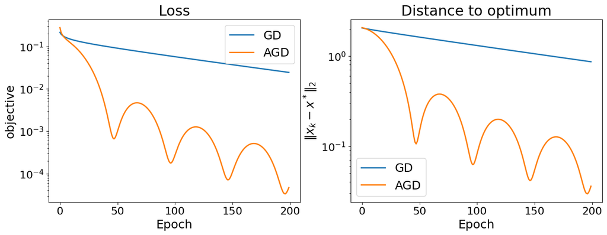

```python
monitors = [monitor_gd, monitor_agd]

solvers = ["GD", "AGD"]

plot_epochs(monitors, solvers)
```

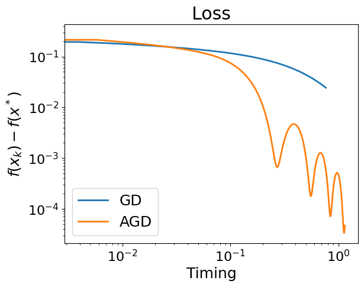

```python
plot_time(monitors, solvers, xscale='log')
```

### First conclusions

*QUESTIONS*:

- Give some first conclusions about the batch solver studied here
- What do you observe about AGD? is it suprising ?

As a first conclusion, we can notice that AGD converges faster than GD. This is not surprising since AGD is an accelerated version of GD (Nesterov acceleration). This is consistent with the theory as the gradient descent algorithm is guaranteed to converge as follows: $$ f(w^T) - f(w^*) \le \frac{L}{2T}\Vert w^0 - w^* \Vert^2 = O\left(\frac{1}{T}\right) $$

While AGD converges as follows : $$ f(w^T) - f(w^*) \le \frac{2\Vert y^0 - x^* \Vert^2}{t(t+1)} = O\left(\frac{1}{T^2}\right) $$

However, we can notice that the convergence of AGD is not monotonic because accelerated gradient descent (Nesterov acceleration) oscillates around the optimal solution while converging to it. In fact, Nesterov acceleration utilizes a momentum term, which causes the algorithm to overshoot the minimum and then oscillate around it.

## 4. Stochastic methods

```python
n_iter = 50

# generate indices of random samples
random_indices = np.random.randint(0, n, n * n_iter)
```

### SGD

We recall that an iteration of SGD writes

- Pick $i$ uniformly at random in $\{1, \ldots, n\}$
- Apply $$ x_{t+1} \gets x_t - \frac{\eta_0}{\sqrt{t+1}} \nabla f_i(x_t) $$

where $\eta_0$ is a step-size to be tuned by hand.

*QUESTION*:

- Fill in the iteration of the SGD solver in the cell below

```python
@njit
def sgd(x_init, random_indices, grad_i, n_iter=100, step=1., store_every=n, args=()):
    """Stochastic gradient descent algorithm."""
    x = x_init.copy()
    x_list = []
    for idx in range(n_iter):
        i = random_indices[idx]
        x = x - (step/np.sqrt(idx + 1)) * grad_i(i, x, *args)

        # Update metrics after each iteration.
        if idx % store_every == 0:
            x_list.append(x.copy())
    return x, x_list
```

```python
step0 = 1e-1
x_init = np.zeros(d)

monitor_sgd = monitor(sgd, loss, x_min, (A, b ,lbda))
monitor_sgd.run(x_init, random_indices, grad_i, n_iter * n, step0, args=(A, b, lbda))
```

### SAG

We recall that an iteration of SAG writes

For $t=1, \ldots, $ until convergence

1. Pick $i_t$ uniformly at random in $\{1, \ldots, n\}$
2. Update the average of gradients $$ G_t \gets \frac 1n \sum_{i=1}^n g_i^t $$ where $$ g_i^t = \begin{cases} \nabla f_{i}(x_t) &\text{ if } i = i_t \\ g_i^{t-1} & \text{ otherwise.} \end{cases} $$
3. Apply the step $$x_{t+1} \gets x_t - \eta G_t$$ where $\eta$ is the step-size (see code below).

*QUESTION*:

- Fill in the iteration of the SAG solver in the cell below

```python
@njit
def sag(x_init, random_indices, grad_i, n_iter=100, step=1., store_every=n, args=()):
    """Stochastic average gradient algorithm."""
    x = x_init.copy()
    # Old gradients
    gradient_memory = np.zeros((n, d))
    averaged_gradient = np.zeros(d)
    x_list = []
    for idx in range(n_iter):
        i = random_indices[idx]
        gi = grad_i(i, x, *args)
        averaged_gradient += (gi - gradient_memory[i])/n
        gradient_memory[i] = gi
        x = x - step * averaged_gradient

        # Update metrics after each iteration.
        if idx % store_every == 0:
            x_list.append(x.copy())
    return x, x_list
```

```python
max_squared_sum = np.max(np.sum(A ** 2, axis=1))
step = 1.0 / (max_squared_sum + lbda)

x_init = np.zeros(d)
monitor_sag = monitor(sag, loss, x_min, (A, b ,lbda))
monitor_sag.run(x_init, random_indices, grad_i, n_iter * n, step, args=(A, b, lbda))
```

### SVRG

We recall that an iteration of SVRG writes

For $k=1, \ldots, $ until convergence

1. Set $\tilde x \gets \tilde x^{(k)}$ and $x_1^{(k)} \gets \tilde x$
2. Compute $\mu_k \gets \nabla f(\tilde x)$
3. For $t=1, \ldots, n$ 4. Pick $i$ uniformly at random in $\{1, \ldots, n\}$ 5. Apply the step $$ x_{t+1}^{(k)} \gets x_t^{(k)} - \eta \big(\nabla f_{i}(x_t^{(k)}) - \nabla f_{i}(\tilde x) + \mu_k \big) $$
4. Set $\tilde x^{(k+1)} \gets x_{n+1}^{(k)}$

where $\eta$ is the step-size (see code below).

*QUESTION*:

- Fill in the iteration of the SVRG solver in the cell below

```python
@njit
def svrg(x_init, random_indices, grad, grad_i, n_iter=100, step=1., store_every=n, args=()):
    """Stochastic variance reduction gradient algorithm."""
    x = x_init.copy()
    x_old = x.copy()
    mu = grad(x_old, *args)
    x_list = []
    for idx in range(n_iter):
        i = random_indices[idx]
        gt = grad_i(i, x, *args) - grad_i(i, x_old, *args) + mu
        x = x - step * gt

        # Update metrics after each iteration.
        if idx % store_every == 0:
            x_list.append(x.copy())
            x_old = x.copy()
            mu = grad(x_old, *args)
    return x, x_list
```

```python
x_init = np.zeros(d)
monitor_svrg = monitor(svrg, loss, x_min, (A, b ,lbda))
monitor_svrg.run(x_init, random_indices, grad, grad_i, n_iter * n, step, args=(A, b, lbda))
```

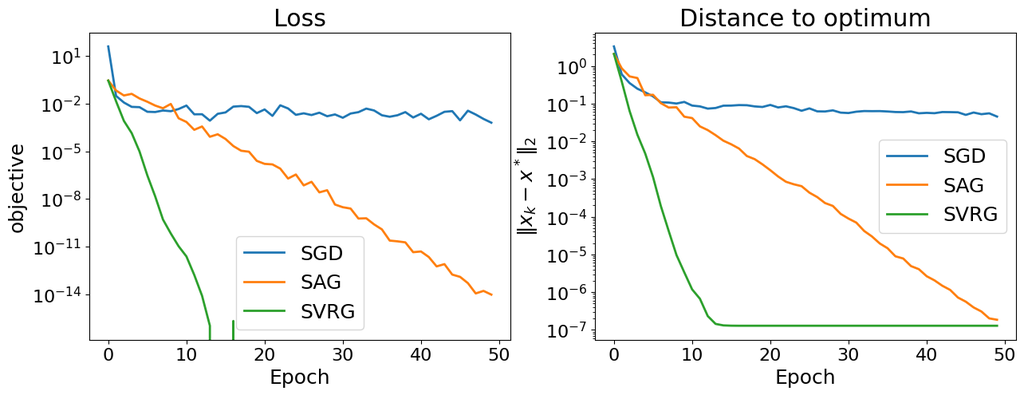

```python
monitors = [monitor_sgd, monitor_sag, monitor_svrg]

solvers = ["SGD", "SAG", "SVRG"]

plot_epochs(monitors, solvers)
```

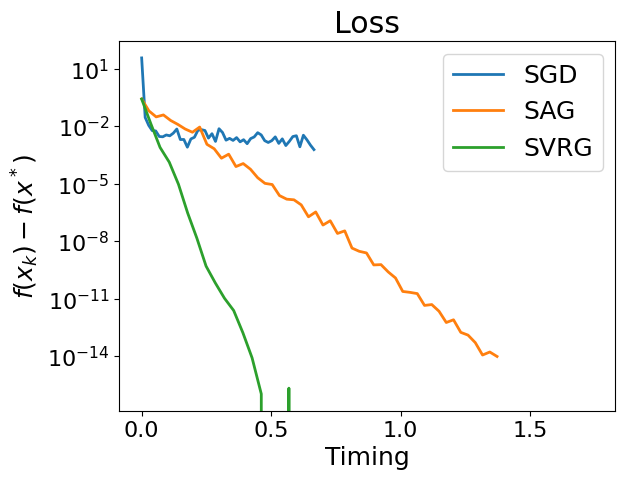

```python
plot_time(monitors, solvers)
```

## 5. Numerical comparison

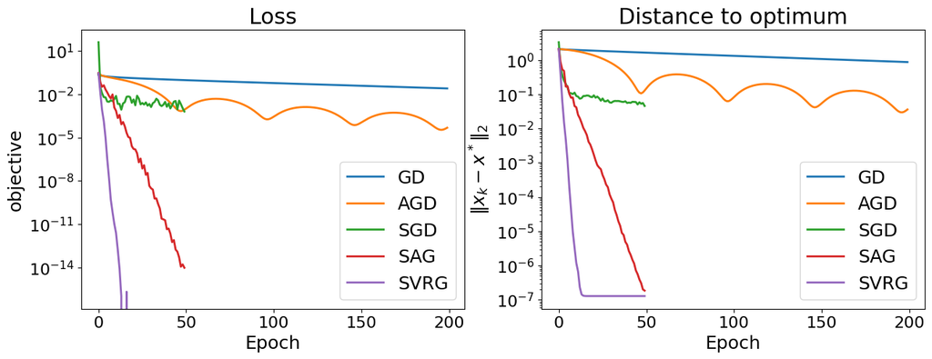

```python
monitors = [monitor_gd, monitor_agd,
            monitor_sgd, monitor_sag, monitor_svrg]

solvers = ["GD", "AGD", "SGD", "SAG", "SVRG"]

plot_epochs(monitors, solvers)
```

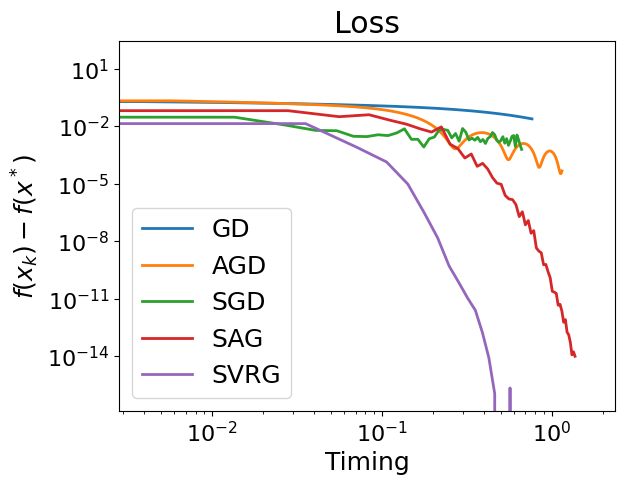

```python
plot_time(monitors, solvers, xscale='log')
```

## 6. Conclusion

*QUESTIONS*:

- Compare and comment your results
- Change the value of the ridge regularization (the `lbda` parameter) to low ridge $\lambda = 1 / n$ and high ridge regularization $\lambda = 1$ and compare your results. Comment.
- Play also with the level of correlation between features (parameter `corr` above), and compare results with low and high correlation.
- Conclude

#### 6.2. Change the value of the ridge regularization (the `lbda` parameter) to low ridge $\lambda = 1 / n$ and high ridge regularization $\lambda = 1$ and compare your results. Comment.

```python
low_ridge = 1/n
high_ridge = 1
ridge_list = [low_ridge, high_ridge]
```

```python
def get_all_monitors(x_model_truth, n, n_iter, d, ridge_list=[1./n**(0.5)], corrs=[0.9]):
    all_monitors = []
    for corr in corrs:
        A, b = simu_linreg(x_model_truth, n, std=1., corr=corr)
        loss = loss_linreg
        grad = grad_linreg
        grad_i = grad_i_linreg
        random_indices = np.random.randint(0, n, n * n_iter)
        monitors = []
        for ridge in ridge_list:
            x_init = np.zeros(d)
            x_min, f_min, _ = fmin_l_bfgs_b(loss, x_init, grad,
                                        args=(A, b, ridge), pgtol=1e-30, factr=1e-30)

            # GD
            step = 1. / lipschitz_linreg(A, b, ridge)
            x_init = np.zeros(d)
            monitor_gd = monitor(gd, loss, x_min, (A, b ,ridge))
            monitor_gd.run(x_init, grad, n_iter, step, args=(A, b, ridge))

            # AGD
            step = 1. / lipschitz_linreg(A, b, ridge)
            x_init = np.zeros(d)
            monitor_agd = monitor(agd, loss, x_min, (A, b ,ridge))
            monitor_agd.run(x_init, grad, n_iter, step, args=(A, b, ridge))

            # SGD
            step0 = 1e-1
            x_init = np.zeros(d)
            monitor_sgd = monitor(sgd, loss, x_min, (A, b ,ridge))
            monitor_sgd.run(x_init, random_indices, grad_i, n_iter * n, step0, args=(A, b, ridge))

            # SAG
            max_squared_sum = np.max(np.sum(A ** 2, axis=1))
            step = 1.0 / (max_squared_sum + ridge)
            x_init = np.zeros(d)
            monitor_sag = monitor(sag, loss, x_min, (A, b ,ridge))
            monitor_sag.run(x_init, random_indices, grad_i, n_iter * n, step, args=(A, b, ridge))

            # SVRG
            x_init = np.zeros(d)
            monitor_svrg = monitor(svrg, loss, x_min, (A, b ,ridge))
            monitor_svrg.run(x_init, random_indices, grad, grad_i, n_iter * n, step, args=(A, b, ridge))

            monitors.append([monitor_gd, monitor_agd, monitor_sgd, monitor_sag, monitor_svrg])
        all_monitors.append(monitors)
    return all_monitors
```

```python
def print_all_monitors(monitors, param_list=[], param="lambda"):
    solvers = ["GD", "AGD", "SGD", "SAG", "SVRG"]

    f, axes = plt.subplots(2, 5, figsize=(25, 8))

    for i, monitors_row in enumerate(np.array(monitors).squeeze().T):

        for j, monit in enumerate(monitors_row) :
            axes[0, i].semilogy(monit.obj, lw=2, label = f"{param} = {param_list[j]}")
            axes[1, i].semilogy(monit.err, lw=2, label = f"{param} = {param_list[j]}")

        axes[0, i].set_title(f"Loss ({solvers[i]})")
        axes[0, i].set_xlabel("Epoch")
        axes[0, i].set_ylabel("Loss")
        axes[0, i].legend(loc="upper right", prop={'size': 12})

        axes[1, i].set_title(f"Distance to optimum ({solvers[i]})")
        axes[1, i].set_xlabel("Epoch")
        axes[1, i].set_ylabel("$\|x_k - x^*\|_2$")
        axes[1, i].legend(loc="upper right", prop={'size': 12})
    plt.tight_layout()
```

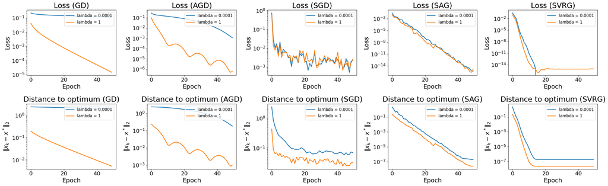

```python
monitors = get_all_monitors(x_model_truth, n, n_iter, d, ridge_list=ridge_list)[0]
print_all_monitors(monitors, ridge_list)
```

Let our two values of lambda be :

- low ridge : $\lambda_{low} = 1 / n$
- high ridge : $\lambda_{high} = 1$

From looking at the plots above we distinguish two cases :

  Consequently, eventhough stochastic methods depend on $L$ (SAG and SVRG), the convergence isn't affected by the value of $\lambda$ when $n \gg L$. Theory and experiment are once again consistent as the convergence of SGD, SAG and SVRG don't depend on $\lambda$.

#### 6.3. Play also with the level of correlation between features (parameter `corr` above), and compare results with low and high correlation.

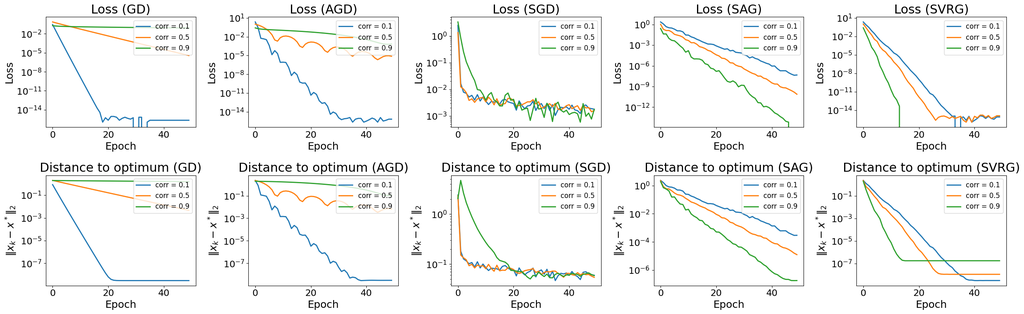

```python
corrs=[0.1, 0.5, 0.9]
monitors = get_all_monitors(x_model_truth, n, n_iter, d, corrs=corrs)
print_all_monitors(monitors, corrs, "corr")
```

Firsty, we observe two different behaviours for our two categories of algorithms (stochastic and non-stochastic) :

- Non-stochastic methods : The lower the correlation, the faster the convergence. From a theoretical point of view, this is a sensible observation. In fact, highly correlated features imply higher $L$. As the upper bound of the convergence theorems for GD and AGD are proportionate to $L$, then the convergence is slower for highly correlated features. This is consistent with the experiment as the convergence is faster for low correlation. (see non-stochastic convergence theorems below) $$ \begin{equation*} \left\{ \begin{aligned} & \text{GD convergence : } f(w^T) - f(w^*) \le \frac{L}{2T}\Vert w^0 - w^* \Vert^2 \\ & \text{AGD convergence : } f(w^T) - f(w^*) \le \frac{2\Vert y^0 - w^* \Vert^2}{t(t+1)} \end{aligned} \right. \end{equation*} $$
- Stochastic methods with variance reduction : The higher the correlation the faster the convergence. It is an expected result as the upper bound of the convergence theorems for SAG and SVRG are inversly bounded to L. Consequently, the higher $L$, the lower the convergence bound and the faster the convergence. (see stochastic convergence theorems below) $$ \begin{equation*} \left\{ \begin{aligned} & \text{SAG convergence : } \mathbb{E}\left[\Vert w^t - w^* \Vert^2\right] \le \left(1 - \min\left\{ \frac{1}{8n}, \frac{\mu}{16L_{max}} \right\}\right)^t C_0 \\ & \text{SVRG convergence : } \mathbb{E}\left[\Vert w^t - w^* \Vert^2\right] \le \rho \mathbb{E}\left[\Vert w^{t-1} - w^* \Vert^2\right] \text{ with } \rho(a, b) = \frac{1}{1-\frac{2a}{L}} \left( \frac{1}{\frac{n\mu}{L}} + \frac{2b}{L} \right) \end{aligned} \right. \end{equation*} $$
- Stochastic methods without variance reduction : As it doesn't depend on $L$ at all, the correlation doesn't affect the convergence of SGD. (see SGD convergence theorem below) $$ \begin{equation*} \left\{ \begin{aligned} & \text{SGD convergence : } \mathbb{E}\left[\Vert w^t - w^* \Vert^2\right] \le (1 - \alpha \mu)^t \Vert w^0 - w^* \Vert^2_2 + \frac{\alpha}{\mu}B^2 \\ \end{aligned} \right. \end{equation*} $$

Finally, comparing our results with the experiment on $\lambda$ previously conducted, we can conclude that in most cases the correlation between features has a greater impact on the convergence than the value of $\lambda$. For instance, let's consider GD results ; with the lambda experiment, the final losses go from $10^{-1}$ to $10^{-5}$ while with the correlation experiment, the final losses go from $10^{-1}$ to $10^{-15}$ which is a much wider range. In addition, 3 of the 5 algorithms we considered are not affected by the value of lambda (SGD, SAG, SVRG) while only 1 isn't affected by the varying correlation (SGD). These arguments are to be considered in the context of our experiment. Another setup (other algorithms or models) could lead to different results.

#### 6.4. Conclude

As a conclusion, we discovered trough this lab that choosing between stochastic and non-stochastic methods isn't trivial and strongly depends on the application and the data.

Our three interresting observations :

- Stochastic methods (SAG and SVRG) are more performant for high-correlation data while non-stochastic methods thrive for low-correlation data.
- Stochastic methods are not affected by the value of $\lambda$ while non-stochastic methods are.
- SGD doesn't depend on $L$ so it is affected neither by the correlation nor by the value of $\lambda$.

Finally, even though individual performances can be discussed depending on the setup, stochastic methods with variance reduction (SAG and SVRG) are the best overall methods. Note that there exists other stochastic methods with variance reduction that are also very powerful such as SAGA.